# Chevrolet Sedans vs Hatchbacks

### Background

The following was inspired by Prof. Garrett Saunder’s “Civic Vs Corolla” analysis which can be viewed here: Civic vs Corolla

Chevrolet is one of the most popular vehicle manufacturers in the world, with a sizable influence in many European nations. In smaller countries like where I served my mission in Czech Republic and Slovakia, smaller more compact vehicle models are preferred due to space and gas efficiency. Hatchbacks and sedans are generally more popular due to this necessity, with hatchbacks being the most numerous and manufactured.

The goal of this analysis is to compare the price and mileage of several individual Chevrolet hatchback and sedan vehicles to see which is the better deal, with a keen interest if hatchbacks offer better value than their sedan counterparts. The Malibu was randomly chosen to be a test model for this analysis due to its popularity. While the background of this study is interest in European vehicle preferences, the following data was gathered from American sources. However, given the global market, we are assuming our conclusion shall hold true for both American and European vehicle trends.

### The Data

While the following data originally included many different makes and models, we filtered the set to only include what we are interested in: Malibu sedans and hatchbacks. Their individual price, mileage, trim, and other specs can be seen below. While price includes more than two decimal spots, these are rough estimates calculated based on market and haven’t been rounded to their respective MSRP.

```r
datatable(CarPrices2, options = list(lengthMenu = c(5, 10, 15)))
```

|  | Price | Mileage | Make | Model | Trim | Type | Cylinder | Liter | Doors | Cruise | Sound | Leather |
| --- | --- | --- | --- | --- | --- | --- | --- | --- | --- | --- | --- | --- |
| 1 | 18957.89004 | 5936 | Chevrolet | Malibu | LS MAXX Hback 4D | Hatchback | 6 | 3.5 | 4 | 0 | 1 | 1 |
| 2 | 18950.90698 | 8687 | Chevrolet | Malibu | LS MAXX Hback 4D | Hatchback | 6 | 3.5 | 4 | 0 | 1 | 1 |
| 3 | 17891.63378 | 17020 | Chevrolet | Malibu | LS MAXX Hback 4D | Hatchback | 6 | 3.5 | 4 | 0 | 1 | 1 |
| 4 | 17801.22953 | 19386 | Chevrolet | Malibu | LS MAXX Hback 4D | Hatchback | 6 | 3.5 | 4 | 1 | 1 | 1 |
| 5 | 16723.99388 | 19740 | Chevrolet | Malibu | LS MAXX Hback 4D | Hatchback | 6 | 3.5 | 4 | 1 | 1 | 1 |
| 6 | 16744.03025 | 21829 | Chevrolet | Malibu | LS MAXX Hback 4D | Hatchback | 6 | 3.5 | 4 | 0 | 1 | 1 |
| 7 | 16825.19088 | 23460 | Chevrolet | Malibu | LS MAXX Hback 4D | Hatchback | 6 | 3.5 | 4 | 0 | 1 | 1 |
| 8 | 16543.98014 | 24583 | Chevrolet | Malibu | LS MAXX Hback 4D | Hatchback | 6 | 3.5 | 4 | 0 | 1 | 1 |
| 9 | 16143.95729 | 26532 | Chevrolet | Malibu | LS MAXX Hback 4D | Hatchback | 6 | 3.5 | 4 | 1 | 1 | 1 |
| 10 | 14914.20128 | 33906 | Chevrolet | Malibu | LS MAXX Hback 4D | Hatchback | 6 | 3.5 | 4 | 0 | 1 | 1 |

[output cut: 50 more lines]

### Two - Line Regression Model

The following display the models to be considered for our analysis, with first preference given to the full model which will be explained.

#### Full Model

$$\underbrace{Y_i}_{\text{Price}} = \overbrace{\beta_0 + \beta_1 \underbrace{X_{i1}}_{\text{Mileage}}}^{\text{Sedan Line}} + \overbrace{\beta_2 \underbrace{X_{i2}}_{\text{Car Models}} + \beta_3 \underbrace{X_{i1} X_{i2}}_{\text{Interaction Between Mileage and Model}}}^{\text{Hatchback Line After Adjustments}} + \epsilon_i$$

With the full model, there are quite many variables as you can see! In a multiple linear regression, the variables, with a focus on the betas, are labeled below in explanatory detail.

$\beta_0$ is the y intercept for our Sedan line, or in other words, the average price of a Sedan when mileage is 0.

$\beta_1$ is our slope, or our average change in y (price) for every increase in x (mileage), for our Sedan vehicles.

$X_{i2}$ is a variable indicating two values, 0 and 1, indicating Sedan and Hatchback respectively (our factor with two groups).

$\beta_2$ is the **change** in our y intercept which will be used to calculate the starting price for our new Hatchback line.

$\beta_3$, in a similar fashion to $\beta_2$, is the **change** in our slope which will be used to calculate the slope of our Hatchback line.

Because $\beta_0$ and $\beta_1$ is representative of the Y-intercept and slope for our line 0 (Sedans) respectively, and it is logical to assume vehicles lose value over mileage and that their starting price is greater than 0, it is therefore not necessary to create a hypothesis based on the relation of these two alone. As with our two-line linear regression model however, we are interested in testing if there is a difference from 0 with $\beta_2$ and $\beta_3$ (that there exists a difference in starting price and rate of value change between Sedans and Hatchbacks as these beta variables influence that).

#### Equal Y-Intercept Test

This model is based on the assumption $\beta_2$ is 0, or that there is no difference or change in the y-intercept between our two vehicle models. This nullifies the middle part of our full model and has Sedan and Hatchback share the same y-intercept but still maintain separate slopes (if they exist.)

If $\beta_2$ is 0, then both sedan and hatchback share the same average starting price. If it is not 0, then both sedans and hatchback have their own starting value.

$$H_0: \beta_2 = 0 \quad \text{(Average Cost For New Vehicle Is Same)} \\
H_a: \beta_2 \neq 0 \quad \text{(Average Cost For New Vehicle Is Not The Same)} \\
\alpha = 0.05$$

#### Equal Slope Test

If $\beta_3$ is 0, then the third part of our full model equation gets nullified and both sedan and hatchback will share the same slope, but have different y-intercepts. If $\beta_3$ is not 0, then sedan and hatchback have different slopes and either increase or decrease at different rates.

$$H_0: \beta_3 = 0 \quad \text{(Equal rates of depreciation)} \\
H_a: \beta_3 \neq 0 \quad \text{(Non-equal rates of depreciation)} \\
\alpha = 0.05$$

### Graphical Summary and Test

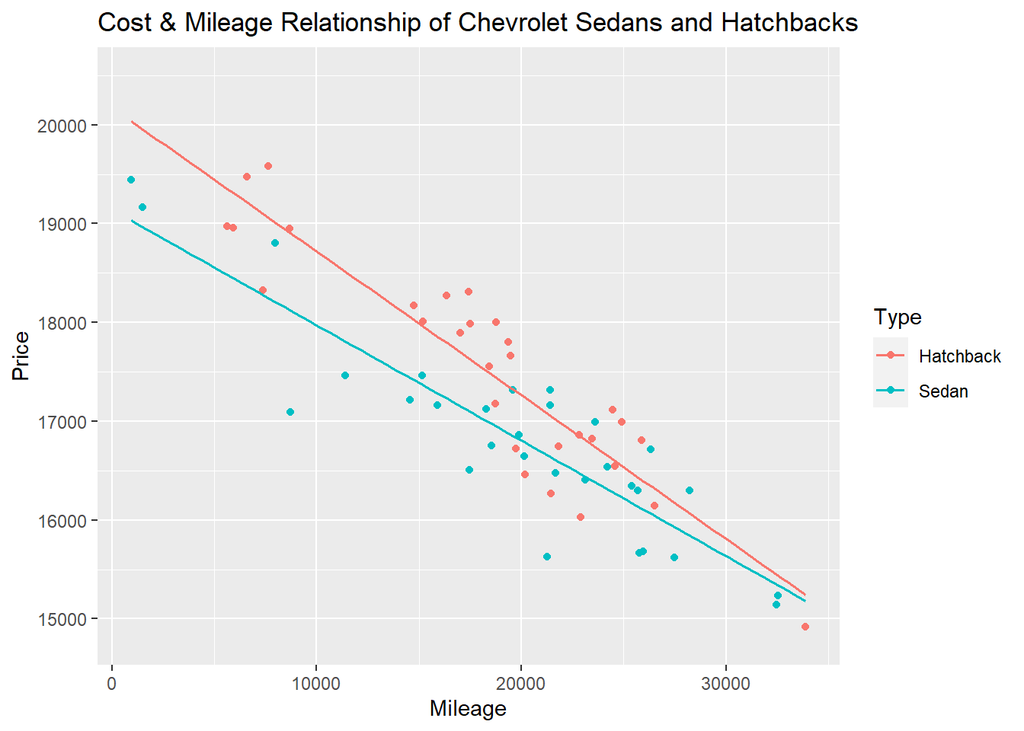

```r
my.lm <- lm(Price ~ Mileage + Type + Mileage:Type, data = CarPrices2)

gf_point(Price ~ Mileage, data = CarPrices2, color = ~ Type) %>%
  gf_lm() %>%
  gf_theme(legend.position = "right") %>%
  gf_labs(title = "Cost & Mileage Relationship of Chevrolet Sedans and Hatchbacks")
```

Our test for this analysis can be seen with more specific estimates.

```r
summary(my.lm) %>%
  pander(caption = "Linear Regression for Chevrolet Sedan/Hatchback Car Prices")
```

|  | Estimate | Std. Error | t value | Pr(>\|t\|) |
| --- | --- | --- | --- | --- |
| **(Intercept)** | 20173 | 238.9 | 84.42 | 9.997e-61 |
| **Mileage** | -0.1455 | 0.01226 | -11.86 | 6.572e-17 |
| **TypeSedan** | -1032 | 332.2 | -3.107 | 0.002962 |
| **Mileage:TypeSedan** | 0.02865 | 0.01635 | 1.752 | 0.08524 |

Linear Regression for Chevrolet Sedan/Hatchback Car Prices

| Observations | Residual Std. Error | $R^2$ | Adjusted $R^2$ |
| --- | --- | --- | --- |
| 60 | 457.7 | 0.8393 | 0.8307 |

### Diagnostics

To ensure our test meets the assumptions necessary for a linear regression, included are three separate graphs which help us determine the appropriateness of our study.

```r
par(mfrow = c(1,3))
plot(my.lm, which = 1)
qqPlot(my.lm$residuals)
```

```
## [1] 58 51
```

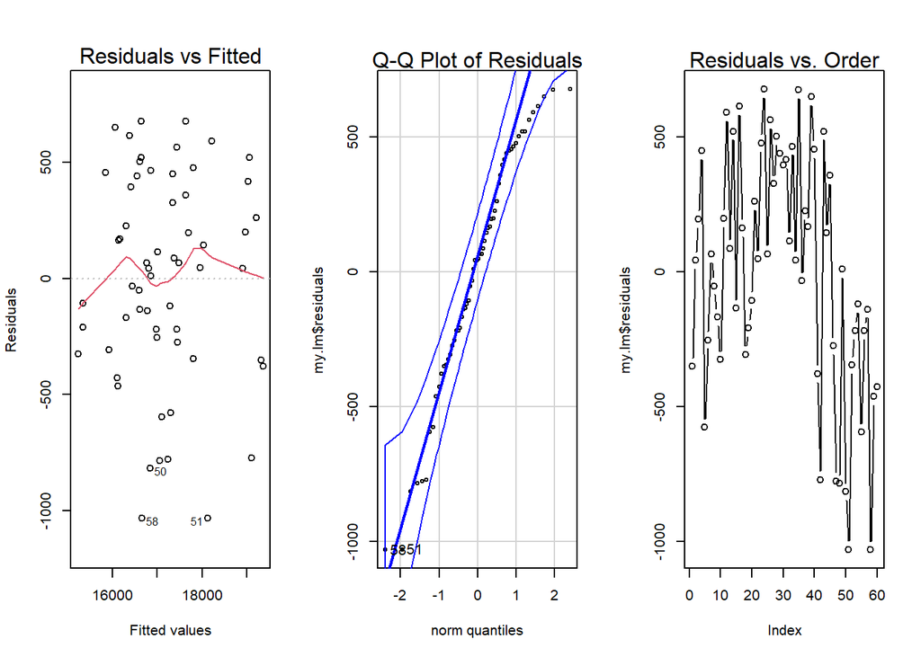

```r
mtext(side = 3,text = "Q-Q Plot of Residuals")
plot(my.lm$residuals, type = "b")
mtext(side = 3, text="Residuals vs. Order")
```